# 7.4 Kernel density estimation

A **density surface** represents how the concentration of point records varies across an area. It is especially useful when overlapping points make those concentrations difficult to see on a point map.

We will use Tara’s nest records from the Forest Geo patch to construct a density surface. We will count nests within raster cells, smooth those counts with a Gaussian kernel, and compare several bandwidths. We will then locate the highest density and examine whether it describes where birds nested or where the crew had already looked.

In completing this lesson, you will learn how to:

- Build an empty raster over a vector with `rast()`, and count points in its cells with `rasterize()`
- Build a Gaussian kernel with `focalMat()`, and describe what its bandwidth controls
- Smooth a count raster into a density surface with `focal()`, and convert the result to a density per hectare
- Blank the cells outside a study area with `mask()`
- Choose a bandwidth by comparing the surfaces it produces
- Locate the maximum of a surface with `where.max()`

**Important!** Before starting this tutorial, be sure that you have completed all preliminary and previous lessons!

## Data for this lesson

**`nests.csv`**: Bird nests found and monitored in a nest monitoring study area, provided as a tabular dataset with one row per nest. Locations were recorded with a handheld GPS unit in a geodetic Coordinate Reference System with the datum WGS 84 and EPSG code 4326.

The data include the following variables:

- `nest_id`, character: The **primary key** for each nest.
- `patch_id`, character: A **foreign key** to the habitat patch in the `patches.geojson` data.
- `species_code`, character: A four-letter code for the species that built the nest. Artificial nests are coded `ARNE`, and nests of unknown species `UNKN`.
- `common_name`, character: The common name of the species that built the nest.
- `discovery_date`, date: The date on which the nest was found. Not recorded for every nest.
- `discovery_stage`, character: The stage of the nest when it was found: Building, Incubation, Nestling, or Inactive.
- `height_m`, numeric: The height of the nest above the ground, in meters.
- `nest_fate`, character: The outcome of the nesting attempt: Success, Failure, or Unknown.
- `longitude`, numeric: The longitude of the nest, in decimal degrees.
- `latitude`, numeric: The latitude of the nest, in decimal degrees.

**`patches.geojson`**: A polygon shapefile of habitat patches in a nest monitoring study area. The data are in a projected Coordinate Reference System with the datum WGS 84 and EPSG code 32617 (UTM Zone 17N).

The data include the following fields:

- `patch_id`, character: The **primary key** for each habitat patch.
- `patch_label`, character: The name of each habitat patch.

## Set up your session

Begin with a clean session:

1. Ensure that your **Global Environment** is empty.
2. In the *History* tab of your **workspace pane**, ensure that your **session history** is empty.

Next:

1. Create a script file.
2. Save your script file as `scripts/kernel_density.R`.
3. Add metadata as a comment on the top of the file.
4. Create a **code section** called “`setup`” after the metadata.
5. Attach *tidyterra*, *sf*, *tmap*, and the packages that comprise the **core tidyverse**, then load the module 3 source script and set the *tmap* mode to view.

Your script should look something like:

```r
# My code for the kernel density tutorial

# setup --------------------------------------------------------

library(tidyterra)
library(sf)
library(tmap)
library(tidyverse)

# Load the source script:

source("scripts/source_script_module_3.R")

# Draw interactive maps:

tmap_mode("view")
```

Next, please create a code section called “`read and pre-process data`”. A density is a count per unit of area, so we will work in the projected CRS used for the campus in *7.3 Raster operations*. Let’s read the habitat patches:

```r
patches <-
  st_read(
    "data/raw/shapefiles/patches.geojson",
    quiet = TRUE
  ) %>%
  st_transform(26917)
```

The study area for this lesson is the Forest Geo patch and the ground within 50 meters of it, because a nest recorded just outside the patch is in the same piece of forest as one just inside it:

```r
forest_geo <-
  patches %>%
  filter(patch_id == "forest_geo")

study_area <-
  forest_geo %>%
  st_buffer(dist = 50)
```

Forest Geo covers 1.5 hectares, and the buffer brings the study area to 7.

Please read the nest records, remove the artificial nests, and keep the ones that fall in the study area. The crew placed artificial nests at locations where they had already found a real nest, so leaving them in would count those locations twice (see *7.3 Raster operations*):

```r
nests <-
  read_csv(
    "data/raw/nests.csv",
    show_col_types = FALSE
  ) %>%

  # Remove the artificial nests:

  filter(!species_code %in% "ARNE") %>%

  # Convert to a simple features object:

  st_as_sf(
    coords = c("longitude", "latitude"),
    crs = 4326
  ) %>%
  st_transform(26917) %>%

  # Keep the nests in the study area:

  st_filter(study_area)
```

```
Simple feature collection with 29 features and 8 fields
Geometry type: POINT
Dimension:     XY
Bounding box:  xmin: 746423.9 ymin: 4308697 xmax: 746660.4 ymax: 4308921
Projected CRS: NAD83 / UTM zone 17N
# A tibble: 29 × 9
   nest_id patch_id   species_code common_name    discovery_date discovery_stage
 * <chr>   <chr>      <chr>        <chr>          <date>         <chr>
 1 N010    forest_geo UNKN         Unknown        2026-05-19     Inactive
 2 N017    forest_geo EATO         Eastern towhee 2026-05-27     Incubation
 3 N024    forest_geo UNKN         Unknown        2026-06-02     Inactive
 4 N025    forest_geo UNKN         Unknown        2026-06-02     Inactive
 5 N026    forest_geo UNKN         Unknown        2026-06-02     Inactive
 6 N027    forest_geo UNKN         Unknown        2026-06-02     Inactive
 7 N028    forest_geo UNKN         Unknown        2026-06-02     Inactive
 8 N029    forest_geo UNKN         Unknown        2026-06-02     Inactive
 9 N041    forest_geo WEVI         White-eyed vi… 2026-06-05     Inactive
10 N043    forest_geo FISP         Field sparrow  2026-06-06     Incubation
# ℹ 19 more rows
# ℹ 3 more variables: height_m <dbl>, nest_fate <chr>, geometry <POINT [m]>
```

That leaves 29 nests. `!species_code %in% "ARNE"` rather than `species_code != "ARNE"`, because two records have no species code and `!=` would discard them along with the artificial nests (see *2.1 Introduction to subsetting and extraction*).

## Density surfaces

A **kernel density estimate** begins by counting records within raster cells, then smooths those counts so that each record contributes to its cell and neighboring cells. The resulting raster contains higher values where records are concentrated and lower values where they are sparse.

Building one takes steps that are each an operation we have used on rasters before:

1. A grid: an empty raster whose cells will contain the counts.
2. Counts: the number of records in each cell, from `rasterize()`.
3. A kernel: a focal window whose weights spread each count across its neighborhood, applied with `focal()`.

The choices that shape the result are the size of the cells and the width of the kernel. This lesson uses a fixed cell size and varies the width, because the width is the choice that changes what the surface shows.

### Creating the grid

We have always taken a grid from a raster we read from a file. `rast()` also builds one from a vector, using its extent and a resolution we choose. Let’s build a grid of five-meter cells over the study area:

```r
template <-
  study_area %>%
  terra::vect() %>%
  terra::rast(resolution = 5)
```

```
class       : SpatRaster
size        : 67, 77, 1  (nrow, ncol, nlyr)
resolution  : 5, 5  (x, y)
extent      : 746386, 746771, 4308641, 4308976  (xmin, xmax, ymin, ymax)
coord. ref. : NAD83 / UTM zone 17N (EPSG:26917)
```

The printed summary has no `source` or `values` lines, because the raster contains no values. It is a grid and nothing else, and the extent is the bounding box of the study area, so the grid is a rectangle around a rounded shape.

### Counting records

`rasterize()` with `fun = "length"` counts the points that fall in each cell, and `background = 0` fills cells without a point (see *6.4 Rasters and vectors together*). Let’s count the nests:

```r
counts <-
  nests %>%
  terra::vect() %>%
  terra::rasterize(
    template,
    fun = "length",
    background = 0
  )

counts %>%
  terra::global(
    c("sum", "max")
  )
```

```
          sum max
V1_length  29   1
```

The sum is the number of nests, and the maximum is one: on a five-meter grid no two nests share a cell.

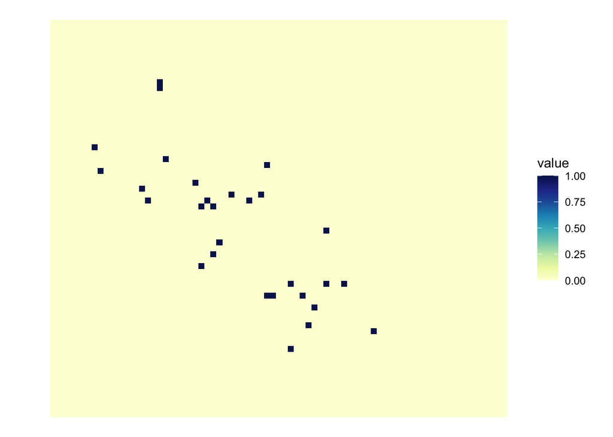

```r
ggplot() +

  # Add the raster layer:

  geom_spatraster(data = counts) +

  # Define the scale:

  scale_fill_whitebox_c(palette = "deep") +

  # Define the theme:

  theme_void()
```

This count raster shows the limitation of displaying the raw cells. Nearly every cell is empty, each occupied cell is a single pixel, and a nest recorded one meter across a cell boundary would count in a different cell. The pattern in the records is there, and the grid is too fine to show it.

## Gaussian kernels

A **kernel** is a matrix of weights centered on a cell, with weights that sum to 1. `focal()` applies those weights to calculate a weighted sum of the surrounding counts (see *7.1 Map algebra*). Except where the kernel extends beyond the raster boundary, smoothing preserves the total count.

`focalMat()` builds the matrix. We supply the following arguments:

- The raster the matrix will be applied to, which sets the size of a cell (typically passed to the function via a pipe)
- The width of the kernel, in the units of the CRS (`d =`)
- The shape of the weights (`type =`), which is `"circle"`, `"rectangle"`, or `"Gauss"`

Let’s build a Gaussian kernel with a bandwidth of 25 meters:

```r
kernel <-
  counts %>%
  terra::focalMat(
    d = 25,
    type = "Gauss"
  )

dim(kernel)
```

```
[1] 31 31
```

```r
sum(kernel)
```

```
[1] 1
```

The matrix is 31 cells on each side, and its weights sum to 1. Let’s inspect its middle row:

```r
kernel[16, 11:21]
```

```
 [1] 0.003876022 0.004640441 0.005337778 0.005899157 0.006263940 0.006390480
 [7] 0.006263940 0.005899157 0.005337778 0.004640441 0.003876022
```

The weight is largest at the center and falls away in both directions. For `type = "Gauss"`, `d =` is the standard deviation of the bell, which the documentation calls sigma, and the matrix extends to three times that distance on each side of the center. A nest in the central cell therefore contributes well under one percent of itself to that cell and the rest to the cells around it, out to 75 meters.

The width of the kernel is the **bandwidth** of the estimate, and it is the decision that shapes the surface.

A kernel is a focal window whose weights were chosen for you

`focal()` with `w = 3` and `fun = "mean"` is a kernel too: a three-by-three matrix in which every weight is one ninth. The Gaussian kernel differs in giving the nearest cells more weight than the farthest, so that the surface has no visible edge at the limit of the window.

`type = "circle"` returns a kernel with equal weights inside a radius of `d` and zero outside it, which is the kernel a plain moving average uses. The choice of shape changes the surface much less than the choice of width does, and the Gaussian shape is the usual one because its surface is smooth.

## Calculating the density surface

Let’s apply the kernel. `fun = "sum"` combines the weighted counts, and `na.rm = TRUE` keeps the cells at the edge of the raster, where part of the window falls outside it. What should the result look like? A raster on the same grid as `counts`, with a sum close to the original count and a smaller maximum. The sum will be slightly smaller when part of a kernel extends beyond the raster boundary:

```r
smoothed <-
  counts %>%
  terra::focal(
    w = kernel,
    fun = "sum",
    na.rm = TRUE
  )

smoothed %>%
  terra::global(
    c("sum", "max")
  )
```

```
               sum        max
focal_sum 28.85387 0.03940342
```

The sum is close to the number of counts and a little below it, because the part of the kernel that falls outside the raster carries weight that reaches no cell. The maximum is the value of the cell at the center of the densest neighborhood, in nests per cell.

The isolated pixels of the count map have become a surface with a peak, a plateau, and a margin. That is the estimate: a smoothed version of the counts, in which each cell describes its neighborhood rather than itself.

### Nests per hectare

The cell values are nests per cell, and a cell is 25 square meters, so the numbers are small and tied to the grid we chose. `mask()` blanks every cell outside the study area, so that the surface is drawn only where we set out to estimate it, and dividing by the cell area in hectares gives nests per hectare, a density that can be compared across grids:

```r
density_25 <-
  smoothed %>%
  terra::mask(
    terra::vect(study_area)
  ) / 0.0025

density_25 %>%
  terra::global("max", na.rm = TRUE)
```

```
               max
focal_sum 15.76137
```

The peak of the surface is about 16 nests per hectare. The number depends on the bandwidth as well as the records, which is the reason to state both when reporting a density.

Let’s draw it in *tmap*, so that the peak can be placed against the campus on the basemap:

```r
density_25 %>%
  tm_shape(name = "Nest density") +
  tm_raster(
    col.scale =
      tm_scale_continuous(values = "brewer.blues"),
    col.legend =
      tm_legend(title = "Nests per hectare")
  )
```

[interactive chart not shown]

The blank corners are the cells the mask removed. Without the mask, the rectangle would be filled to its corners, and a reader would be offered an estimate for ground the study never covered.

**Note**

Recall that a local operation applies to every cell of a raster (see *7.1 Map algebra*). Division is a local operation, and the result retains the grid of the input.

## Selecting a bandwidth

The bandwidth determines the scale represented by the surface. Notice what happens when we make it narrow:

```r
density_10 <-
  counts %>%
  terra::focal(
    w =
      terra::focalMat(
        counts,
        d = 10,
        type = "Gauss"
      ),
    fun = "sum",
    na.rm = TRUE
  ) %>%
  terra::mask(
    terra::vect(study_area)
  ) / 0.0025

density_50 <-
  counts %>%
  terra::focal(
    w =
      terra::focalMat(
        counts,
        d = 50,
        type = "Gauss"
      ),
    fun = "sum",
    na.rm = TRUE
  ) %>%
  terra::mask(
    terra::vect(study_area)
  ) / 0.0025
```

Let’s compare the three bandwidths directly:

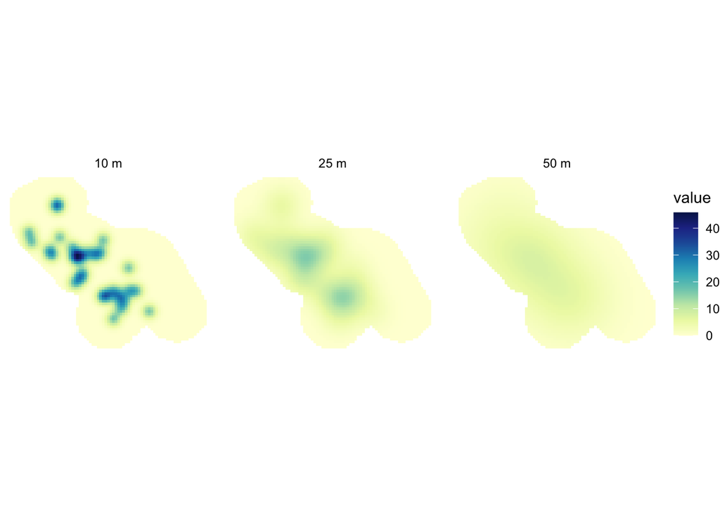

```r
density_comparison <-
  c(
    density_10,
    density_25,
    density_50
  ) %>%
  rename(
    `10 m` = 1,
    `25 m` = 2,
    `50 m` = 3
  )

ggplot() +

  # Add the raster layer:

  geom_spatraster(data = density_comparison) +

  # Define the scale:

  scale_fill_whitebox_c(palette = "deep") +

  # Draw the layers separately:

  facet_wrap(~lyr) +

  # Define the theme:

  theme_void()
```

At 10 meters the surface is a field of small peaks, so it shows the nests more than their broader concentration. At 50 meters the surface is a single hill across the patch, and the detail within it is gone.

Let’s compare the maxima:

```r
density_comparison %>%
  terra::global("max", na.rm = TRUE)
```

```
          max
10 m 45.83410
25 m 15.76137
50 m  7.76314
```

A narrow bandwidth produces a high, sharp peak, and a wide one produces a low, broad one. Neither is wrong, because each describes the records at a different scale, and the bandwidth to report is the one that matches the scale of the question. A question about where within a patch the nests cluster is a question at the scale of a territory, and 25 meters answers it. A question about which patches hold nests at all is a question at the scale of a patch.

Choose the bandwidth from the question, and report it with the map!

A density surface with no stated bandwidth cannot be read, because the same records produce a field of spots at one bandwidth and a single hill at another.

Choose the bandwidth to match the scale of the process or the decision: the size of a territory, a park, or a management unit. Draw the surface at a bandwidth on either side of it to see what changes. Then report the bandwidth in the caption, beside the cell size and the number of records.

Check your understanding

A density surface is built twice from the same records, once with `d = 10` and once with `d = 40`. Which statement is correct?

The surface built with d = 10 has the higher maximum The surface built with d = 40 has the higher maximum The two surfaces have the same maximum, because they sum to the same total The surface built with d = 40 sums to a larger total

True or false: The weights of a kernel returned by `focalMat()` sum to one.

## Interpreting the density surface

A density surface is a raster, so the tools of module 6 read it. `where.max()` returns the cell number and value of the maximum, and `xyFromCell()` returns the coordinates of a cell (see *6.1 Introduction to rasters with terra*). Let’s find the peak:

```r
peak <-
  density_25 %>%
  terra::where.max() %>%
  as_tibble()

peak
```

```
# A tibble: 1 × 3
  layer  cell value
  <dbl> <dbl> <dbl>
1     1  2415  15.8
```

```r
density_25 %>%
  terra::xyFromCell(peak$cell)
```

```
            x       y
[1,] 746523.5 4308818
```

Let’s determine which patch contains the peak:

```r
peak_point <-
  density_25 %>%
  terra::xyFromCell(peak$cell) %>%
  st_point() %>%
  st_sfc(crs = 26917)

patches %>%
  st_filter(peak_point) %>%
  st_drop_geometry()
```

```
    patch_id patch_label
1 forest_geo  Forest Geo
```

The densest nesting in the study area is inside Forest Geo rather than in the 50-meter collar around it, which is what we would hope to see from a patch that was chosen for a nest search.

### Where the crew had already looked

The surface describes where nests were found. Whether that is where the birds nested, or where the crew searched hardest, is a question the surface cannot answer alone. The artificial nests are the record of that search, because the crew placed each one at a location where a real nest had already been found. Let’s read them and measure how far each sits from the nearest real nest:

```r
artificial <-
  read_csv(
    "data/raw/nests.csv",
    show_col_types = FALSE
  ) %>%

  # Keep the artificial nests:

  filter(species_code %in% "ARNE") %>%
  st_as_sf(
    coords = c("longitude", "latitude"),
    crs = 4326
  ) %>%
  st_transform(26917) %>%
  st_filter(study_area)

artificial %>%
  mutate(
    nearest =
      st_nearest_feature(geometry, nests),
    nearest_distance =
      st_distance(
        geometry,
        nests$geometry[nearest],
        by_element = TRUE
      ) %>%
      as.numeric()
  ) %>%
  st_drop_geometry() %>%
  summarize(
    artificial_nests = n(),
    farthest = max(nearest_distance)
  )
```

```
# A tibble: 1 × 2
  artificial_nests farthest
             <int>    <dbl>
1               12        0
```

Every artificial nest in the study area is at the location of a real one. A density surface built from them therefore cannot describe where birds chose to nest. Let’s build it anyway and see what it does describe:

```r
artificial_density <-
  artificial %>%
  terra::vect() %>%
  terra::rasterize(
    template,
    fun = "length",
    background = 0
  ) %>%
  terra::focal(
    w = kernel,
    fun = "sum",
    na.rm = TRUE
  ) %>%
  terra::mask(
    terra::vect(study_area)
  ) / 0.0025

artificial_density %>%
  terra::global("max", na.rm = TRUE)
```

```
               max
focal_sum 9.299389
```

Twelve nests over the same ground give a lower peak than 29 do. Let’s draw it beside the surface above:

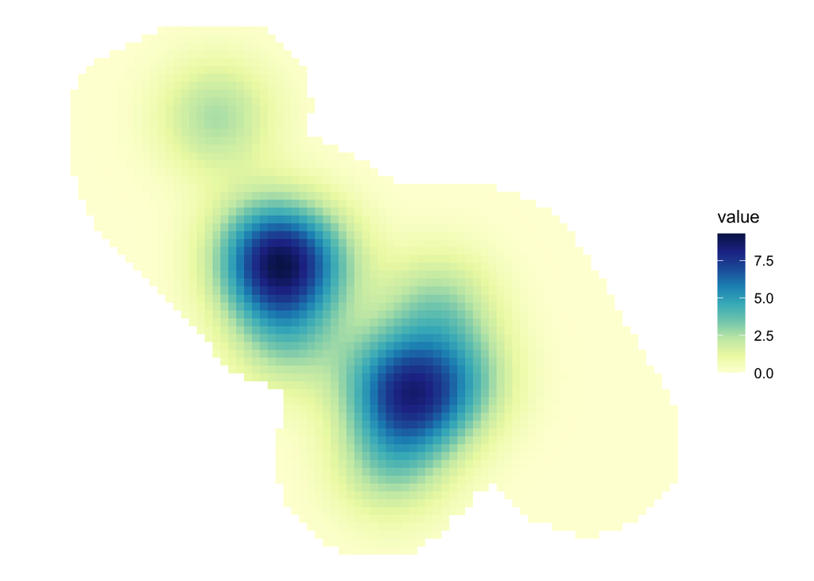

```r
ggplot() +

  # Add the raster layer:

  geom_spatraster(data = artificial_density) +

  # Define the scale:

  scale_fill_whitebox_c(palette = "deep") +

  # Define the theme:

  theme_void()
```

The peak of this surface falls about seven meters from the peak of the real-nest surface, on a grid of five-meter cells. That is the point: the artificial nests carry no information about where birds nested, yet their surface reproduces the real one, because both describe the same search. A density surface repeats how the records were collected, and looks like a result while doing it.

A density of records is a density of effort until you show otherwise!

Field records are made where the crew walked, when they walked there, and where the habitat made a nest easy to see. A density surface of records inherits all of that, and a peak in it is evidence about the search before it is evidence about the birds.

Before reading a peak as biology, build the surface for something that describes the search rather than the birds, and compare. A peak that survives the comparison is worth investigating. A peak that the search surface reproduces describes where the crew looked.

## Putting it all together

A kernel density estimate is a sequence of operations we already have, and the decisions sit between them. My own model of the workflow looks like this (click to expand):

[figure not shown]

**Note**

This workflow shows *my* mental model for these steps. Your model may differ. What matters is that it helps you retrieve the functions needed to solve a problem.

## Take-home points

- A kernel density estimate is a count raster smoothed with a kernel. `rast()` builds the grid from a vector and a resolution, `rasterize()` with `fun = "length"` counts the records, `focalMat()` builds the kernel, and `focal()` with `fun = "sum"` applies it.
- A kernel’s weights sum to 1, so smoothing preserves the count except where part of the kernel extends beyond the raster boundary.
- The bandwidth `d =` is the standard deviation of a Gaussian kernel, and it determines the scale represented by the surface. A narrow bandwidth shows the records, and a wide bandwidth shows a broad concentration. Choose it from the scale of the question and report it with the map.
- Divide the surface by the cell area to turn records per cell into a density in the units of the question, so that surfaces built on different grids can be compared.
- `mask()` blanks the cells outside the study area, so that a reader is not offered an estimate for ground the study never covered.
- `where.max()` and `xyFromCell()` locate the peak of a density surface.
- A density of field records reflects the search as well as the birds. Build a surface from something that describes the search, and read a peak as biology only if it survives the comparison.

## Exercises

Test your knowledge!

1. A density surface is built from 29 nests on a grid of five-meter cells, and the cells are then divided by the cell area in hectares. What does a cell value of 16 mean?

About 16 nests per hectare in the neighborhood of that cell 16 nests fell in that cell 16 nests fell within the bandwidth of that cell That cell contains 16 times the mean density

2. Two analysts build density surfaces from the same records. One reports a peak of 46 nests per hectare and the other a peak of 8. What is the most likely explanation?

The first used a narrower bandwidth The first used a coarser grid The second masked the surface to the study area The second built the surface from fewer records

3. A peak in a nest-density surface may describe the crew’s search rather than the birds. Which change provides the most direct test of that, using the workflow from this lesson?

Build a surface from records that describe the search, with the same grid and kernel, and compare the two Increase the bandwidth until the peak disappears Use a smaller cell size while keeping every record Mask the completed surface to the study boundary

4. Parsons problem: Reorder the lines to smooth the count raster named `counts` with the existing kernel named `kernel`, then convert the result to nests per hectare. Each raster cell represents 0.0025 hectares.

## Reference

- **Bandwidth**: The width of a kernel, which for a Gaussian kernel is its standard deviation, and which decides the scale a density surface describes.
- **Code section**: A portion of an R script file that is delineated by a section header.
- **Density surface**: A raster in which each cell contains the number of records per unit of area around it.
- **Global environment**: A workspace that provides a reference point for all user-assigned objects associated with the current session.
- **Kernel**: A matrix of weights that sum to one, centered on a cell, that spreads a count across the cells around it.
- **Kernel density estimate**: A density surface built by counting records in the cells of a grid and smoothing the counts with a kernel.
- **Session history**: All lines of code that have been sent to R since the beginning of a session (or since the session history was last cleared).
- **Workspace pane**: A pane of RStudio used to view/manage objects in your global environment and your session history.

**Important!** Primitive functions, as well as functions in the packages that R attaches by default (e.g., *base*, *utils*, *stats*, and *graphics*), are available as soon as you start an R session.

| Package | Function | Definition |
| --- | --- | --- |
| .Primitive | ! | Prefix logical operator (not) |
| .Primitive | $ | Infix operator that extracts the values associated with a name (RHS) from a recursive object (LHS) |
| .Primitive | + | Infix arithmetic operator (addition) |
| .Primitive | / | Infix arithmetic operator (divide) |
| .Primitive | : | Infix operator that generates a regular sequence of adjacent values |
| .Primitive | :: | Infix operator that can be used to access a package environment without attaching the whole package environment to your current session |
| .Primitive | <- | Infix operator that assigns an object on the right-hand-side (RHS) to a name on the left-hand-side (LHS) -- this should be used for global assignments! |
| .Primitive | = | Infix operator that assigns an object on the right-hand-side (RHS) to a name on the left-hand-side (LHS) -- this should not be used for global assignments! |
| .Primitive | == | Infix relational operator (is equal to) |
| .Primitive | [...] | Extraction operator used to index multiple values from a data object (LHS) based on the position or values specified inside the brackets |
| .Primitive | as.numeric | Transform an atomic vector to a double numeric vector (i.e., decimal numbers) |
| .Primitive | c | Combine values to form an atomic vector |
| .Primitive | max | Return the highest value in a numeric vector (integer or double) as a one-value numeric or integer vector (depending on input) |
| .Primitive | sum | Calculate the sum of the values in a numeric vector. |
| .Primitive | ~ | The formula operator separates the left- and right-hand sides (LHS and RHS) in a formula. |
| base | %in% | Infix relational operator that tests whether the values on the left-hand-side (LHS) are found within the vector on the right-hand-side (RHS) |
| base | dim | Return the dimensions (number of rows and columns, or array dimensions) of a data object. |
| base | library | Attach the package environment for a given package to the current R session |
| base | source | Execute a source script (in its entirety) |
| dplyr | filter | Subset a data frame by logical condition |
| dplyr | mutate | Add or modify a column in a data frame |
| dplyr | n | Calculate the number of observations (rows) |
| dplyr | rename | Change the name assigned to a column in a data frame |
| dplyr | summarize | Calculate one or more summary statistics on a variable or variables in a data frame (often used in conjunction with `group_by()` but may also be used with `.by = ...`) |
| ggplot2 | facet_wrap | Split plot into facets |
| ggplot2 | ggplot | Set the data and, potentially, the aesthetics of a plot |
| ggplot2 | theme_void | A ggplot theme that contains no axes or panel background |
| magrittr | %>% | The pipe operator passes the output of the LHS argument to the function on the right |
| readr | read_csv | Read a tabular csv file into R as a tibble data frame |
| sf | st_as_sf | Convert a data frame to an sf object |
| sf | st_buffer | Create a buffer (shapefile) that extends the boundary of a target shapefile by a given distance |
| sf | st_distance | Calculate the pairwise distance between features in a shapefile (or between different shapefiles) |
| sf | st_drop_geometry | Remove the geometry column from an sf file and (thus) convert to a data frame |
| sf | st_filter | Conduct a filtering join (i.e., subset geometries) of a target table relative to the geometry of a source table |
| sf | st_nearest_feature | Match each feature of one object to the single nearest feature of another object |
| sf | st_point | Convert a vector of coordinates to a single point |
| sf | st_read | Read in a simple features or other GIS shapefile |
| sf | st_sfc | Store a geometry in a simple features column object |
| sf | st_transform | Transform the CRS of a shapefile to a different CRS |
| terra | focal | Return a raster in which each cell is a summary of a window of cells around it. |
| terra | focalMat | Build a matrix of weights that sum to one, of circular, rectangular, or Gaussian shape, for use with focal(). |
| terra | global | Calculate a summary statistic across each cell in a raster |
| terra | mask | A type of join in which you convert all cells in a target raster to NA if they are outside of a source object (e.g., a polygon shapefile or SpatVector) |
| terra | rast | Read in a raster object, create a raster object from scratch, or convert a list of raster objects to a raster stack |
| terra | rasterize | Convert a shapefile to a raster |
| terra | vect | Convert an sf object to a SpatVector (or create a SpatVector from scratch) |
| terra | where.max | Return the cell number and value of the maximum of each layer of a raster. |
| terra | xyFromCell | Return the coordinates of the center of one or more cells, given their cell numbers. |
| tibble | as_tibble | Convert a data frame (and some other non-tibble objects!) to a tibble data frame |
| tidyterra | geom_spatraster | Draw a SpatRaster in a ggplot, mapping its first layer to fill unless another is named. |
| tidyterra | scale_fill_whitebox_c | A continuous fill scale using one of the palettes of the WhiteboxTools software. |
| tmap | tm_legend | Configure a layer's legend (title, position, frame, orientation) in tmap v4. |
| tmap | tm_raster | Add a raster layer to a tmap |
| tmap | tm_scale_continuous | Define a continuous visual-variable scale for a tmap v4 layer. |
| tmap | tm_shape | Define the shape that is the source of a tmap layer |
| tmap | tmap_mode | Set a tmap to either "plot" (static map) or "view" (interactive map) |

The most common keyboard shortcuts are provided below for Windows and Mac operating systems.

| Task | Windows | Mac |
| --- | --- | --- |
| View all keyboard shortcuts | Alt + ⇧ + K | ⌥ + ⇧ + K |
| Open an existing script | Ctrl + O | ⌘ + O |
| Create a new script | Ctrl + ⇧ + N | ⌘ + ⇧ + N |
| Save script file | Ctrl + S | ⌘ + S |
| Execute code | Ctrl + Enter | ⌘ + Return |
| Copy | Ctrl + C | ⌘ + C |
| Paste | Ctrl + V | ⌘ + V |
| Add a pipe operator | Ctrl + ⇧ + M | ⌘ + ⇧ + M |
| Add an assignment operator | Alt + dash | ⌥ + dash |
| Add a new code section | Ctrl + ⇧ + R | ⌘ + ⇧ + R |
| Indent code | Ctrl + I | ⌘ + I |